**Instructions:**

1. **For all questions after 10th, Please only use the data specified in the note given just below the question**
2. **You need to add answers in the same file i.e. PDS_UberDriveProject_Questions.ipynb' and rename that file as 'Name_Date.ipynb'.You can mention the date on which you will be uploading/submitting the file.For e.g. if you plan to submit your assignment on 31-March, you can rename the file as 'STUDENTNAME_31-Mar-2020'**

# Load the necessary libraries. Import and load the dataset with a name uber_drives .

```python
import numpy as np
import pandas as pd
import matplotlib.pyplot as plt
%matplotlib inline
import seaborn as sns
from warnings import filterwarnings
filterwarnings("ignore")
```

```python
# Get the Data
df = pd.read_csv('uberdrive.csv')
df.head()
```

|  | START_DATE* | END_DATE* | CATEGORY* | START* | STOP* | MILES* | PURPOSE* |
| --- | --- | --- | --- | --- | --- | --- | --- |
| 0 | 01-01-2016 21:11 | 01-01-2016 21:17 | Business | Fort Pierce | Fort Pierce | 5.1 | Meal/Entertain |
| 1 | 01-02-2016 01:25 | 01-02-2016 01:37 | Business | Fort Pierce | Fort Pierce | 5.0 | NaN |
| 2 | 01-02-2016 20:25 | 01-02-2016 20:38 | Business | Fort Pierce | Fort Pierce | 4.8 | Errand/Supplies |
| 3 | 01-05-2016 17:31 | 01-05-2016 17:45 | Business | Fort Pierce | Fort Pierce | 4.7 | Meeting |
| 4 | 01-06-2016 14:42 | 01-06-2016 15:49 | Business | Fort Pierce | West Palm Beach | 63.7 | Customer Visit |

## Q1. Show the last 10 records of the dataset. (2 point)

```python
df.tail(10)
```

|  | START_DATE* | END_DATE* | CATEGORY* | START* | STOP* | MILES* | PURPOSE* |
| --- | --- | --- | --- | --- | --- | --- | --- |
| 1145 | 12/30/2016 10:15 | 12/30/2016 10:33 | Business | Karachi | Karachi | 2.8 | Errand/Supplies |
| 1146 | 12/30/2016 11:31 | 12/30/2016 11:56 | Business | Karachi | Karachi | 2.9 | Errand/Supplies |
| 1147 | 12/30/2016 15:41 | 12/30/2016 16:03 | Business | Karachi | Karachi | 4.6 | Errand/Supplies |
| 1148 | 12/30/2016 16:45 | 12/30/2016 17:08 | Business | Karachi | Karachi | 4.6 | Meeting |
| 1149 | 12/30/2016 23:06 | 12/30/2016 23:10 | Business | Karachi | Karachi | 0.8 | Customer Visit |
| 1150 | 12/31/2016 1:07 | 12/31/2016 1:14 | Business | Karachi | Karachi | 0.7 | Meeting |
| 1151 | 12/31/2016 13:24 | 12/31/2016 13:42 | Business | Karachi | Unknown Location | 3.9 | Temporary Site |
| 1152 | 12/31/2016 15:03 | 12/31/2016 15:38 | Business | Unknown Location | Unknown Location | 16.2 | Meeting |
| 1153 | 12/31/2016 21:32 | 12/31/2016 21:50 | Business | Katunayake | Gampaha | 6.4 | Temporary Site |
| 1154 | 12/31/2016 22:08 | 12/31/2016 23:51 | Business | Gampaha | Ilukwatta | 48.2 | Temporary Site |

## Q2. Show the first 10 records of the dataset. (2 points)

```python
df.head(10)
```

|  | START_DATE* | END_DATE* | CATEGORY* | START* | STOP* | MILES* | PURPOSE* |
| --- | --- | --- | --- | --- | --- | --- | --- |
| 0 | 01-01-2016 21:11 | 01-01-2016 21:17 | Business | Fort Pierce | Fort Pierce | 5.1 | Meal/Entertain |
| 1 | 01-02-2016 01:25 | 01-02-2016 01:37 | Business | Fort Pierce | Fort Pierce | 5.0 | NaN |
| 2 | 01-02-2016 20:25 | 01-02-2016 20:38 | Business | Fort Pierce | Fort Pierce | 4.8 | Errand/Supplies |
| 3 | 01-05-2016 17:31 | 01-05-2016 17:45 | Business | Fort Pierce | Fort Pierce | 4.7 | Meeting |
| 4 | 01-06-2016 14:42 | 01-06-2016 15:49 | Business | Fort Pierce | West Palm Beach | 63.7 | Customer Visit |
| 5 | 01-06-2016 17:15 | 01-06-2016 17:19 | Business | West Palm Beach | West Palm Beach | 4.3 | Meal/Entertain |
| 6 | 01-06-2016 17:30 | 01-06-2016 17:35 | Business | West Palm Beach | Palm Beach | 7.1 | Meeting |
| 7 | 01-07-2016 13:27 | 01-07-2016 13:33 | Business | Cary | Cary | 0.8 | Meeting |
| 8 | 01-10-2016 08:05 | 01-10-2016 08:25 | Business | Cary | Morrisville | 8.3 | Meeting |
| 9 | 01-10-2016 12:17 | 01-10-2016 12:44 | Business | Jamaica | New York | 16.5 | Customer Visit |

## Q3. Show the dimension(number of rows and columns) of the dataset. (2 points)

```python
df.shape
print("the number of rows and columns in data frame are :",df.shape)
```

```
the number of rows and columns in data frame are : (1155, 7)
```

## Q4. Show the size (Total number of elements) of the dataset. (2 points)

```python
df.size
print("Total number of elements :" ,df.size)
```

```
Total number of elements : 8085
```

## Q5. Display the information about all the variables of the data set. (2 points)

#### Hint: Information includes - Total number of columns,variable data-types, number of non-null values in a variable, and usage

```python
df.info()
```

```
<class 'pandas.core.frame.DataFrame'>
RangeIndex: 1155 entries, 0 to 1154
Data columns (total 7 columns):
 #   Column       Non-Null Count  Dtype
---  ------       --------------  -----
 0   START_DATE*  1155 non-null   object
 1   END_DATE*    1155 non-null   object
 2   CATEGORY*    1155 non-null   object
 3   START*       1155 non-null   object
 4   STOP*        1155 non-null   object
 5   MILES*       1155 non-null   float64
 6   PURPOSE*     653 non-null    object
dtypes: float64(1), object(6)
memory usage: 63.3+ KB
```

## Q6. Check for missing values. (2 points) - Note: Output should be boolean only.

```python
df.isnull()
```

|  | START_DATE* | END_DATE* | CATEGORY* | START* | STOP* | MILES* | PURPOSE* |
| --- | --- | --- | --- | --- | --- | --- | --- |
| 0 | False | False | False | False | False | False | False |
| 1 | False | False | False | False | False | False | True |
| 2 | False | False | False | False | False | False | False |
| 3 | False | False | False | False | False | False | False |
| 4 | False | False | False | False | False | False | False |
| ... | ... | ... | ... | ... | ... | ... | ... |
| 1150 | False | False | False | False | False | False | False |
| 1151 | False | False | False | False | False | False | False |
| 1152 | False | False | False | False | False | False | False |
| 1153 | False | False | False | False | False | False | False |
| 1154 | False | False | False | False | False | False | False |

1155 rows × 7 columns

## Q7. How many missing values are present? (2 points)

#### Hint: Find out the total number of missing values across all the variables

```python
df.isnull().sum()
```

```
START_DATE*      0
END_DATE*        0
CATEGORY*        0
START*           0
STOP*            0
MILES*           0
PURPOSE*       502
dtype: int64
```

## Q8. Get the summary of the original data. (2 points).

#### Hint: Summary includes- Count,Mean, Std, Min, 25%,50%,75% and max

#### Note:Outcome will contain only numerical column.

```python
df.describe()
```

|  | MILES* |
| --- | --- |
| count | 1155.000000 |
| mean | 10.566840 |
| std | 21.579106 |
| min | 0.500000 |
| 25% | 2.900000 |
| 50% | 6.000000 |
| 75% | 10.400000 |
| max | 310.300000 |

## Q9. Drop the missing values and store data in a new dataframe (name it"df") (2-points)

#### Note: Dataframe "df" will not contain any missing value

```python
new_df= df.copy()
#new_df
#new_df.shape
new_df.dropna(axis=0, inplace=True)
new_df.isnull().sum()
```

```
START_DATE*    0
END_DATE*      0
CATEGORY*      0
START*         0
STOP*          0
MILES*         0
PURPOSE*       0
dtype: int64
```

## Q10. Check the information of the dataframe(df). (2 points)

#### Hint: Information includes - Total number of columns,variable data-types, number of non-null values in a variable, and usage

```python
new_df.info()
```

```
<class 'pandas.core.frame.DataFrame'>
Int64Index: 653 entries, 0 to 1154
Data columns (total 7 columns):
 #   Column       Non-Null Count  Dtype
---  ------       --------------  -----
 0   START_DATE*  653 non-null    object
 1   END_DATE*    653 non-null    object
 2   CATEGORY*    653 non-null    object
 3   START*       653 non-null    object
 4   STOP*        653 non-null    object
 5   MILES*       653 non-null    float64
 6   PURPOSE*     653 non-null    object
dtypes: float64(1), object(6)
memory usage: 40.8+ KB
```

## Q11. Get the unique start locations. (2 points)

#### Note: This question is based on the dataframe with no 'NA' values

#### Hint- You need to print the unique start locations place names in this and not the count.

```python
new_df['START*'].unique()
```

```
array(['Fort Pierce', 'West Palm Beach', 'Cary', 'Jamaica', 'New York',
       'Elmhurst', 'Midtown', 'East Harlem', 'Flatiron District',
       'Midtown East', 'Hudson Square', 'Lower Manhattan',
       "Hell's Kitchen", 'Downtown', 'Gulfton', 'Houston', 'Eagan Park',
       'Morrisville', 'Durham', 'Farmington Woods', 'Lake Wellingborough',
       'Fayetteville Street', 'Raleigh', 'Whitebridge', 'Hazelwood',
       'Fairmont', 'Meredith Townes', 'Apex', 'Chapel Hill', 'Northwoods',
       'Edgehill Farms', 'Eastgate', 'East Elmhurst', 'Long Island City',
       'Katunayaka', 'Colombo', 'Nugegoda', 'Unknown Location',
       'Islamabad', 'R?walpindi', 'Noorpur Shahan', 'Preston',
       'Heritage Pines', 'Tanglewood', 'Waverly Place', 'Wayne Ridge',
       'Westpark Place', 'East Austin', 'The Drag', 'South Congress',
       'Georgian Acres', 'North Austin', 'West University', 'Austin',
       'Katy', 'Sharpstown', 'Sugar Land', 'Galveston', 'Port Bolivar',
       'Washington Avenue', 'Briar Meadow', 'Latta', 'Jacksonville',
       'Lake Reams', 'Orlando', 'Kissimmee', 'Daytona Beach', 'Ridgeland',
       'Florence', 'Meredith', 'Holly Springs', 'Chessington', 'Burtrose',
       'Parkway', 'Mcvan', 'Capitol One', 'University District',
       'Seattle', 'Redmond', 'Bellevue', 'San Francisco', 'Palo Alto',
       'Sunnyvale', 'Newark', 'Menlo Park', 'Old City', 'Savon Height',
       'Kilarney Woods', 'Townes at Everett Crossing', 'Huntington Woods',
       'Weston', 'Seaport', 'Medical Centre', 'Rose Hill', 'Soho',
       'Tribeca', 'Financial District', 'Oakland', 'Emeryville',
       'Berkeley', 'Kenner', 'CBD', 'Lower Garden District', 'Storyville',
       'New Orleans', 'Chalmette', 'Arabi', 'Pontchartrain Shores',
       'Metairie', 'Summerwinds', 'Parkwood', 'Banner Elk', 'Boone',
       'Stonewater', 'Lexington Park at Amberly', 'Winston Salem',
       'Asheville', 'Topton', 'Renaissance', 'Santa Clara', 'Ingleside',
       'West Berkeley', 'Mountain View', 'El Cerrito', 'Krendle Woods',
       'Fuquay-Varina', 'Rawalpindi', 'Lahore', 'Karachi', 'Katunayake',
       'Gampaha'], dtype=object)
```

## Q12. What is the total number of unique start locations? (2 points)

#### Note: Use the original dataframe without dropping 'NA' values

```python
df['START*'].nunique()
```

```
176
```

## Q13. What is the total number of unique stop locations. (2 points)

#### Note: Use the original dataframe without dropping 'NA' values.

```python
df['STOP*'].nunique()
```

```
187
```

## Q14. Display all the Uber trips that has the starting point of San Francisco. (2 points)

#### Note: Use the original dataframe without dropping the 'NA' values.

#### Hint: You need to display the rows which has starting point of San Francisco. Try using loc function

```python
df.loc[df['START*'] == 'San Francisco']
```

|  | START_DATE* | END_DATE* | CATEGORY* | START* | STOP* | MILES* | PURPOSE* |
| --- | --- | --- | --- | --- | --- | --- | --- |
| 362 | 05-09-2016 14:39 | 05-09-2016 15:06 | Business | San Francisco | Palo Alto | 20.5 | Between Offices |
| 440 | 6/14/2016 16:09 | 6/14/2016 16:39 | Business | San Francisco | Emeryville | 11.6 | Meeting |
| 836 | 10/19/2016 14:02 | 10/19/2016 14:31 | Business | San Francisco | Berkeley | 10.8 | NaN |
| 917 | 11-07-2016 19:17 | 11-07-2016 19:57 | Business | San Francisco | Berkeley | 13.2 | Between Offices |
| 919 | 11-08-2016 12:16 | 11-08-2016 12:49 | Business | San Francisco | Berkeley | 11.3 | Meeting |
| 927 | 11-09-2016 18:40 | 11-09-2016 19:17 | Business | San Francisco | Oakland | 12.7 | Customer Visit |
| 933 | 11-10-2016 15:17 | 11-10-2016 15:22 | Business | San Francisco | Oakland | 9.9 | Temporary Site |
| 966 | 11/15/2016 20:44 | 11/15/2016 21:00 | Business | San Francisco | Berkeley | 11.8 | Temporary Site |

## Q15. What is the most popular starting point for the Uber drivers? (2 points)

#### Note: Use the original dataframe without dropping the 'NA' values.

#### Hint:Popular means the place that is visited the most

```python
#df['START*'].value_counts().head(1)

df['START*'].value_counts().idxmax()
```

```
'Cary'
```

## Q16. What is the most popular dropping point for the Uber drivers? (2 points)

#### Note: Use the original dataframe without dropping the 'NA' values.

#### Hint: Popular means the place that is visited the most

```python
#df['STOP*'].value_counts().head(1)

df['STOP*'].value_counts().idxmax()
```

```
'Cary'
```

## Q17. List the most frequent route taken by Uber drivers. (3 points)

#### Note: This question is based on the new dataframe with no 'na' values.

#### Hint-Print the most frequent route taken by Uber drivers (Route= combination of START & END points present in the Data set). One may use Groupby function

```python
#result_df=(new_df.groupby('START*')['STOP*'])
#print(result_df)
#df.groupby(["START*", "STOP*"]).sum()

#print(result_df)
#df.groupby('START*')['STOP*'].sort_values(ascending = False)
#df.groupby(["START*", "STOP*"])['MILES*'].max()
df.groupby(['START*', 'STOP*']).size().sort_values(ascending = False)
```

```
START*            STOP*
Unknown Location  Unknown Location    86
Morrisville       Cary                75
Cary              Morrisville         67
                  Cary                53
                  Durham              36
                                      ..
New York          Long Island City     1
                  Queens               1
                  Queens County        1
Newark            Menlo Park           1
Agnew             Agnew                1
Length: 361, dtype: int64
```

## Q18. Display all types of purposes for the trip in an array. (3 points)

#### Note: This question is based on the new dataframe with no 'NA' values.

```python
new_df['PURPOSE*'].unique()
```

```
array(['Meal/Entertain', 'Errand/Supplies', 'Meeting', 'Customer Visit',
       'Temporary Site', 'Between Offices', 'Charity ($)', 'Commute',
       'Moving', 'Airport/Travel'], dtype=object)
```

## Q19. Plot a bar graph of Purpose vs Miles(Distance). (3 points)

#### Note: Use the original dataframe without dropping the 'NA' values.

#### Hint:You have to plot total/sum miles per purpose

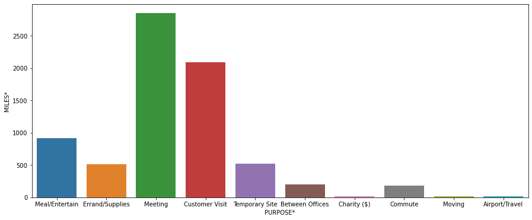

```python
plt.figure(figsize=(15,6))
sns.barplot( x='PURPOSE*', y='MILES*',estimator=np.sum , data=df ,ci = False)
plt.show()
```

## Q20. Display a dataframe of Purpose and the distance travelled for that particular Purpose. (3 points)

#### Note: Use the original dataframe without dropping "NA" values

```python
#df[['PURPOSE*','MILES*']]
df.groupby(["PURPOSE*"])['MILES*'].sum()
```

```
PURPOSE*
Airport/Travel       16.5
Between Offices     197.0
Charity ($)          15.1
Commute             180.2
Customer Visit     2089.5
Errand/Supplies     508.0
Meal/Entertain      911.7
Meeting            2851.3
Moving               18.2
Temporary Site      523.7
Name: MILES*, dtype: float64
```

#### Note: Use the original dataframe without dropping the 'NA' values.

#### Hint : You can make a countplot or barplot.

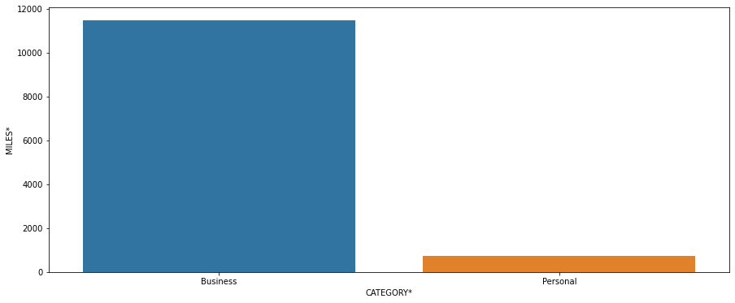

```python
plt.figure(figsize=(15,6))
sns.barplot( x='CATEGORY*', y='MILES*',estimator=np.sum , data=df ,ci = False)
plt.show()
```

## Q22. What is proportion of miles that are covered as Business trips and what is the proportion of miles that are covered as Personal trips? (3 points)

### Note:Use the original dataframe without dropping the 'NA' values. The proportion calculation is with respect to the 'miles' variable.

#### Hint: Proportion of miles covered as business trips= (Total Miles clocked as Business Trips)/ (Total Miles)

#### Proportion of miles covered as personal trips= (Total Miles clocked as Personal Trips)/ (Total Miles)

```python
#df1=df[df.CATEGORY == 'Business']['MILES*'].sum()
#df.groupby(['CATEGORY*', 'MILES*']).size().sort_values(ascending = False)
#df1=df.groupby(["CATEGORY*", "MILES*"]).sum()
#print(df1)
df2=df['MILES*'].sum()
print('Total Miles:', df2)

df3=df['MILES*'][df['CATEGORY*'] == 'Business'].sum()
print('Total miles covered by Business purpose: ',df3)

df4=df['MILES*'][df['CATEGORY*'] == 'Personal'].sum()
print('Total miles covered by Personal purpose: ',df4)

df5=df3/df2
print('Proportion of miles covered as business trips= (Total Miles clocked as Business Trips)/ (Total Miles) :',df5)

df6=df4/df2
print('Proportion of miles covered as personal trips= (Total Miles clocked as Personal Trips)/ (Total Miles) :',df6)
```

```
Total Miles: 12204.7
Total miles covered by Business purpose:  11487.0
Total miles covered by Personal purpose:  717.6999999999999
Proportion of miles covered as business trips= (Total Miles clocked as Business Trips)/ (Total Miles) : 0.9411947856153776
Proportion of miles covered as personal trips= (Total Miles clocked as Personal Trips)/ (Total Miles) : 0.05880521438462231
```